# Assignment 2

# Let’s look at Visib

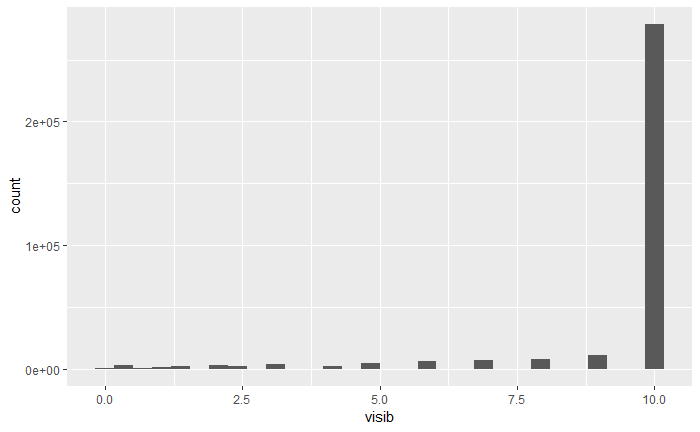

## Hmm, looks discrete

```r
DataSet4$visib %>%
  sort() %>%
  unique()
```

```
 [1]  0.00  0.06  0.12  0.25  0.50  0.75  1.00  1.25  1.50  1.75  2.00  2.50  3.00  4.00  5.00  6.00  7.00  8.00  9.00 10.00
```

After Trial and Error, arrive at this, which is ugly and needs improvement

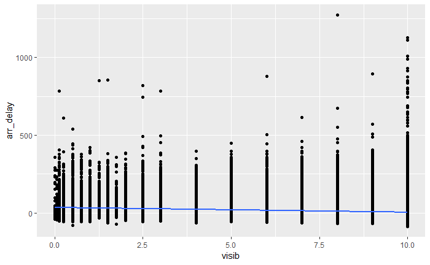

So the LM line appears to visually disagree with the superficial impression of the points. Are outliers affecting this? Let’s check sample sizes.

```r
DataSet4 %>%
  group_by(visib) %>%
  summarise(nObs = n())
```

| visib | nObs |
| --- | --- |
| 0.00 | 110 |
| 0.06 | 93 |
| 0.12 | 440 |
| 0.25 | 1358 |
| 0.50 | 1478 |
| 0.75 | 496 |
| 1.00 | 1474 |
| 1.25 | 208 |
| 1.50 | 1692 |
| 1.75 | 156 |

[output cut: 11 more lines]

Sizes are acceptable. I’m not sure what to think about this relationship. The scale of the graph could be affecting the line. Let’s try a box plot. First, i think I need to purge the NAs. First, how many rows are there before I start.

```r
DataSet4 %>%
  nrow()
```

```
[1] 336776
```

Ok, let’s try something re NA purge.

```r
DataSet4 %>%
  filter(visib == visib, na.rm = T)
```

```
Error: `na.rm` (`na.rm = T`) must not be named, do you need `==`?
Call `rlang::last_error()` to see a backtrace
```

This is what I have in mind, but it doesn’t work yet.

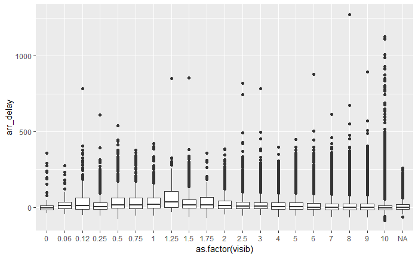

Okay, this kinda works! You could sort of read a trend into this, but it seems to decline around “1”

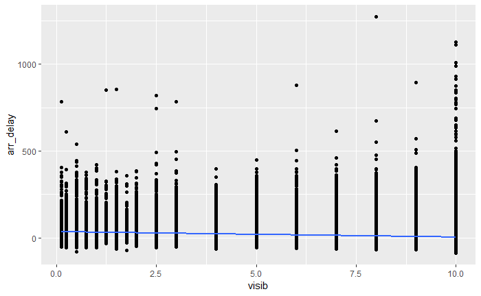